# Similarity Judgment Task Analysis: Syntax

morgan moyer

2025-07-04

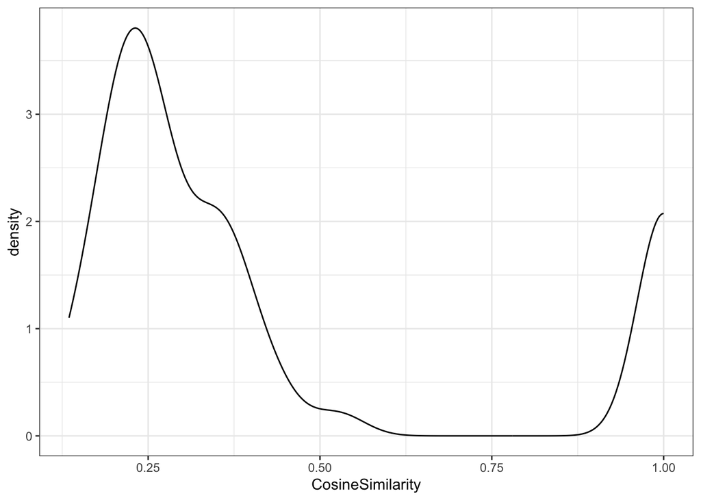

```r
ggplot(d, aes(CosineSimilarity)) +
  geom_density(alpha = .5)
```

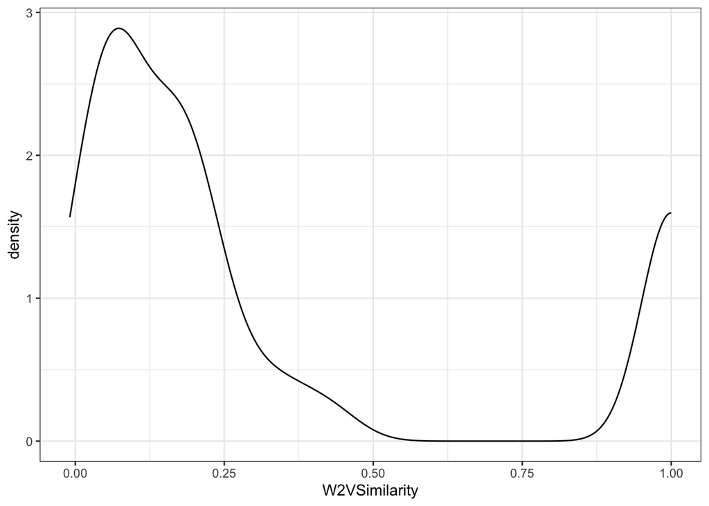

```r
ggplot(d, aes(W2VSimilarity)) +
  geom_density(alpha = .5)
```

```r
names(d)
```

```
## [1] "WordPair"         "X"                "ID.Ibex"          "Response"
## [5] "FeatureMatch"     "Word1"            "Word2"            "W2VSimilarity"
## [9] "CosineSimilarity"
```

```r
dcen <- d %>%
  mutate(WordPair = as.factor(WordPair),
         ID.Ibex = as.factor(ID.Ibex),
         FeatureMatch = as.factor(FeatureMatch),
         cResponse = as.numeric(Response)-mean(as.numeric(Response)))

m <- lmer(cResponse ~ FeatureMatch + (1|WordPair) + (1+FeatureMatch|ID.Ibex), data = dcen)
```

```
## boundary (singular) fit: see help('isSingular')
```

```r
summary(m)
```

```
## Linear mixed model fit by REML. t-tests use Satterthwaite's method [
## lmerModLmerTest]
## Formula: cResponse ~ FeatureMatch + (1 | WordPair) + (1 + FeatureMatch |
##     ID.Ibex)
##    Data: dcen
##
## REML criterion at convergence: 4261.5
##
## Scaled residuals:
##     Min      1Q  Median      3Q     Max
## -2.3506 -0.4752 -0.0004  0.1835  4.1061
##
## Random effects:
##  Groups   Name                            Variance Std.Dev. Corr
##  WordPair (Intercept)                      53.37    7.305
##  ID.Ibex  (Intercept)                     154.10   12.414
##           FeatureMatchMaxMatch            117.42   10.836    0.53
##           FeatureMatchMaxMismatch          35.55    5.962   -0.31 -0.33
##           FeatureMatchSelfPair            154.57   12.432   -1.00 -0.53  0.31
##           FeatureMatchValenceMatchingOnly  74.67    8.641    0.06  0.82  0.16
##  Residual                                 250.06   15.813
##
##
##
##
##
##
##  -0.06
##
## Number of obs: 500, groups:  WordPair, 50; ID.Ibex, 10
##
## Fixed effects:
##                                 Estimate Std. Error      df t value Pr(>|t|)
## (Intercept)                      -20.676      4.822  14.692  -4.288 0.000676
## FeatureMatchMaxMatch              11.060      5.236  21.574   2.112 0.046486
## FeatureMatchMaxMismatch           -2.570      4.385  30.044  -0.586 0.562211
## FeatureMatchSelfPair              85.860      5.580  19.518  15.388 2.25e-12
## FeatureMatchValenceMatchingOnly    9.030      4.811  23.519   1.877 0.072967
##
## (Intercept)                     ***
## FeatureMatchMaxMatch            *
## FeatureMatchMaxMismatch
## FeatureMatchSelfPair            ***
## FeatureMatchValenceMatchingOnly .
## ---
## Signif. codes:  0 '***' 0.001 '**' 0.01 '*' 0.05 '.' 0.1 ' ' 1
##
## Correlation of Fixed Effects:
##             (Intr) FtrMtchMxMt FtrMtchMxMs FtrMSP
## FtrMtchMxMt -0.029
## FtrMtchMxMs -0.480  0.249
## FtrMtchSlfP -0.865  0.025       0.414
## FtrMtchVlMO -0.309  0.614       0.411       0.267
## optimizer (nloptwrap) convergence code: 0 (OK)
## boundary (singular) fit: see help('isSingular')
```

### Plot fixed effect estimates with confidence intervals

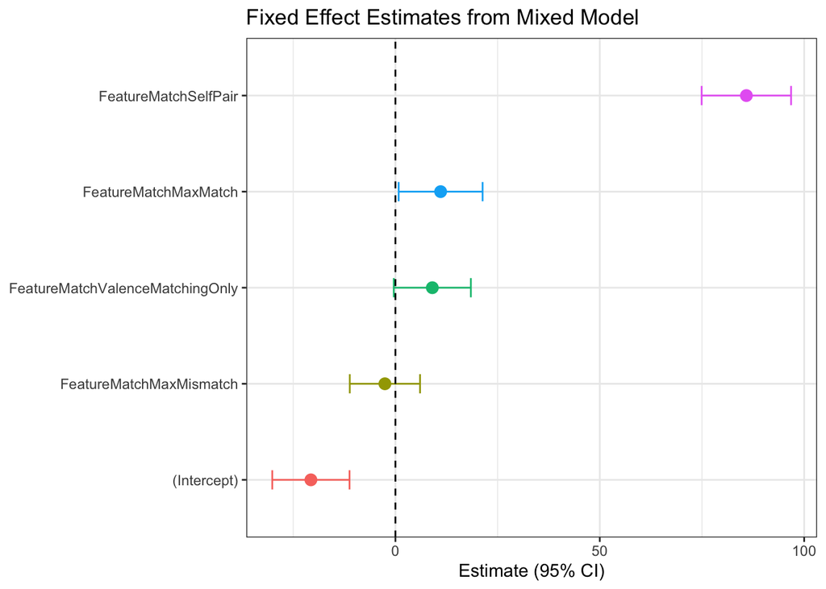

```r
# Tidy the model output
coefs <- tidy(m, effects = "fixed")
# Reorder by effect size for prettier plotting
coefs$term <- factor(coefs$term, levels = coefs$term[order(coefs$estimate)])

# Then replot
ggplot(coefs, aes(x = estimate, y = term, color = term)) +
  geom_point(size = 3) +
  geom_errorbarh(aes(xmin = estimate - 1.96 * std.error,
                     xmax = estimate + 1.96 * std.error), height = 0.2) +
  geom_vline(xintercept = 0, linetype = "dashed") +
  # theme_minimal(base_size = 14) +
  labs(title = "Fixed Effect Estimates from Mixed Model",
       x = "Estimate (95% CI)", y = NULL) +
  theme(legend.position="none")
```

### Plot predicted values vs. predictors

You can create a dataset of predicted values from your model and plot how the response changes with predictors:

```r
newdata <- expand.grid(
  FeatureMatch = levels(dcen$FeatureMatch))
```

2. Get predicted values and standard errors from the model

```r
pred <- predict(m, newdata = newdata, re.form = NA, se.fit = TRUE)
```

3. Add predictions and confidence intervals to newdata

```r
newdata$fit <- pred$fit
newdata$se <- pred$se.fit
newdata <- newdata %>%
  mutate(
    conf.low = fit - 1.96 * se,
    conf.high = fit + 1.96 * se
  )
```

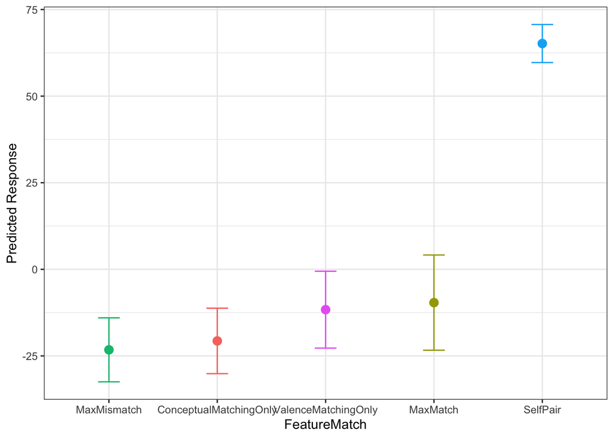

```r
ggplot(newdata, aes(x = reorder(FeatureMatch,fit), y = fit, color = FeatureMatch, fill = FeatureMatch)) +
  geom_point(size = 3) +
  geom_errorbar(aes(ymin = conf.low, ymax = conf.high), width = 0.2) +
  # theme_minimal() +
  labs(x = "FeatureMatch", y = "Predicted Response", color = "FeatureMatch", fill = "FeatureMatch") +
  theme(legend.position="none")
```

## You can visualize individual random effect estimates:

What you get from the plot: A visual summary of the variability in random effects across levels of your grouping factors.

Helps you identify:

Which groups (subjects/items) deviate strongly from the average effect,

How precise these deviations are,

Whether there are outliers or patterns in random effects.

Example interpretation: If a subject’s random intercept dot is far from zero with narrow error bars, that subject consistently differs from the average intercept with high certainty.

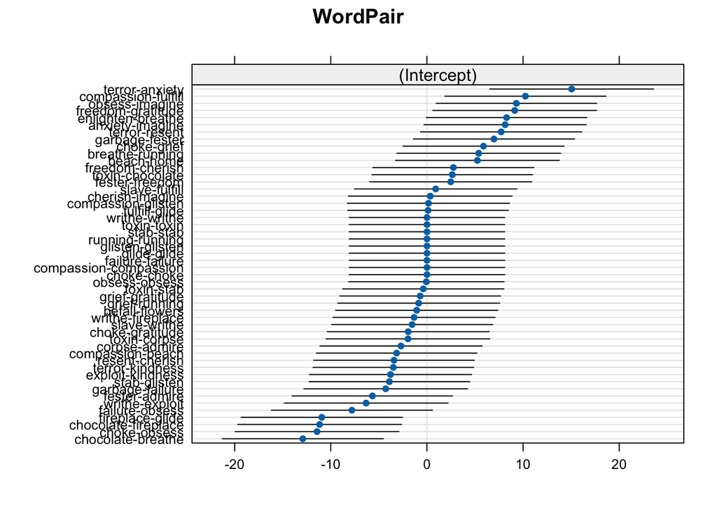

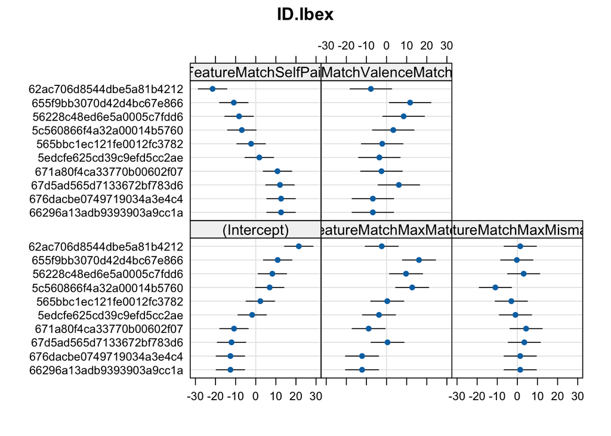

```r
dotplot(ranef(m, condVar=TRUE))
```

## Check model diagnostics

For residuals, fitted vs residuals, etc.:

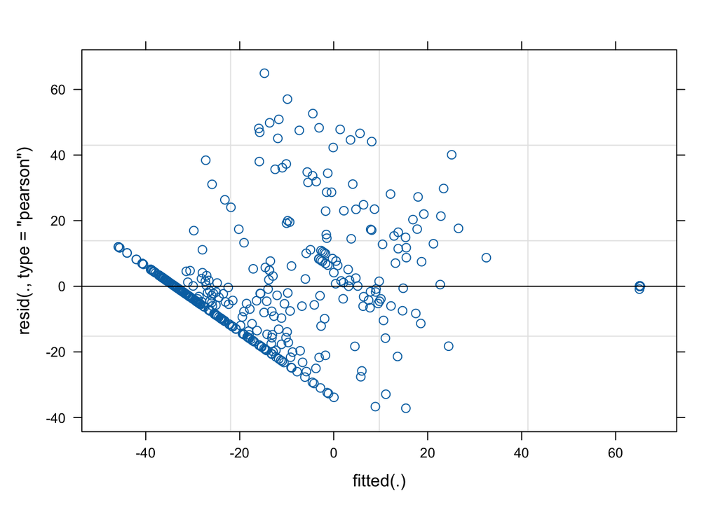

```r
plot(m)
```

# Does Similarity predict or interact with FeatureMatch?

## Cosine Similarity from Transformer Models

- No.

```r
m.full <- lmer(cResponse ~ FeatureMatch*CosineSimilarity + (1|WordPair) + (1|ID.Ibex), data = dcen)
```

```
## fixed-effect model matrix is rank deficient so dropping 1 column / coefficient
```

```r
summary(m.full)
```

```
## Linear mixed model fit by REML. t-tests use Satterthwaite's method [
## lmerModLmerTest]
## Formula: cResponse ~ FeatureMatch * CosineSimilarity + (1 | WordPair) +
##     (1 | ID.Ibex)
##    Data: dcen
##
## REML criterion at convergence: 4299
##
## Scaled residuals:
##     Min      1Q  Median      3Q     Max
## -1.9311 -0.6956 -0.1178  0.4178  3.5367
##
## Random effects:
##  Groups   Name        Variance Std.Dev.
##  WordPair (Intercept)  46.36    6.809
##  ID.Ibex  (Intercept) 128.07   11.317
##  Residual             312.80   17.686
## Number of obs: 500, groups:  WordPair, 50; ID.Ibex, 10
##
## Fixed effects:
##                                                  Estimate Std. Error      df
## (Intercept)                                       -24.772     12.570  46.731
## FeatureMatchMaxMatch                               -7.344     17.004  41.001
## FeatureMatchMaxMismatch                            -3.566     15.703  41.001
## FeatureMatchSelfPair                               74.046     34.041  41.001
## FeatureMatchValenceMatchingOnly                    20.279     17.855  41.001
## CosineSimilarity                                   15.910     45.535  41.001
## FeatureMatchMaxMatch:CosineSimilarity              46.408     55.839  41.001
## FeatureMatchMaxMismatch:CosineSimilarity            7.714     63.939  41.001
## FeatureMatchValenceMatchingOnly:CosineSimilarity  -42.706     66.340  41.001
##                                                  t value Pr(>|t|)
## (Intercept)                                       -1.971   0.0547 .
## FeatureMatchMaxMatch                              -0.432   0.6681
## FeatureMatchMaxMismatch                           -0.227   0.8215
## FeatureMatchSelfPair                               2.175   0.0354 *
## FeatureMatchValenceMatchingOnly                    1.136   0.2627
## CosineSimilarity                                   0.349   0.7286
## FeatureMatchMaxMatch:CosineSimilarity              0.831   0.4107
## FeatureMatchMaxMismatch:CosineSimilarity           0.121   0.9046
## FeatureMatchValenceMatchingOnly:CosineSimilarity  -0.644   0.5233
```

[output cut: 9 more lines]

```
## CosinSmlrty    -0.933  0.689       0.747      -0.993  0.657
## FtrMtchMxMt:CS  0.761 -0.959      -0.609       0.810 -0.535 -0.815
## FtrMtchMxMs:CS  0.664 -0.491      -0.964       0.707 -0.468 -0.712
## FtrMtVMO:CS     0.640 -0.473      -0.512       0.682 -0.975 -0.686
##                FtrMtchMxMt:CS FtrMtchMxMs:CS
## FtrMtchMxMt
## FtrMtchMxMs
## FtrMtchSlfP
## FtrMtchVlMO
## CosinSmlrty
## FtrMtchMxMt:CS
## FtrMtchMxMs:CS  0.581
## FtrMtVMO:CS     0.560          0.489
## fit warnings:
## fixed-effect model matrix is rank deficient so dropping 1 column / coefficient
```

## Does adding Cosine Similarity explain any more variance in the data?

- no

```r
m.s <- lmer(cResponse ~ FeatureMatch + (1|WordPair) + (1|ID.Ibex), data = dcen)

anova(m.s, m.full, REML=FALSE)
```

```
## refitting model(s) with ML (instead of REML)
```

```
## Data: dcen
## Models:
## m.s: cResponse ~ FeatureMatch + (1 | WordPair) + (1 | ID.Ibex)
## m.full: cResponse ~ FeatureMatch * CosineSimilarity + (1 | WordPair) + (1 | ID.Ibex)
##        npar    AIC    BIC  logLik deviance  Chisq Df Pr(>Chisq)
## m.s       8 4378.2 4412.0 -2181.1   4362.2
## m.full   12 4381.2 4431.8 -2178.6   4357.2 5.0333  4     0.2839
```

### Plot fixed effect estimates with confidence intervals

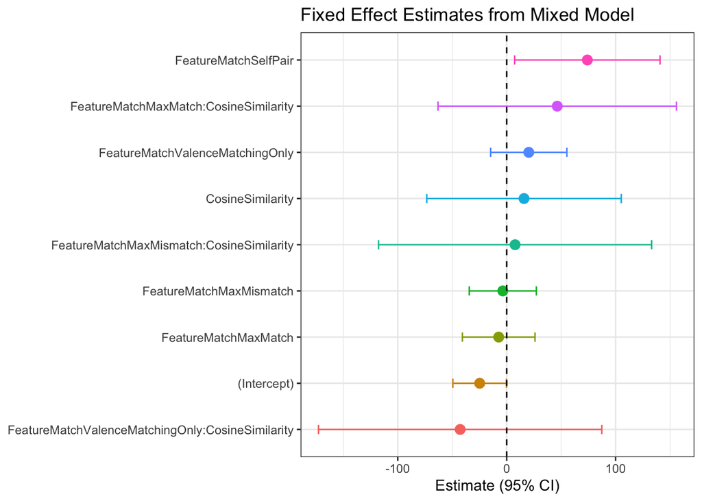

```r
# Tidy the model output
coefs <- tidy(m.full, effects = "fixed")

# Reorder by effect size for prettier plotting
coefs$term <- factor(coefs$term, levels = coefs$term[order(coefs$estimate)])

# Then replot
ggplot(coefs, aes(x = estimate, y = term, color = term)) +
  geom_point(size = 3) +
  geom_errorbarh(aes(xmin = estimate - 1.96 * std.error,
                     xmax = estimate + 1.96 * std.error), height = 0.2) +
  geom_vline(xintercept = 0, linetype = "dashed") +
  # theme_minimal(base_size = 14) +
  labs(title = "Fixed Effect Estimates from Mixed Model",
       x = "Estimate (95% CI)", y = NULL) +
  theme(legend.position="none")
```

## Word-2-Vec Similarity

```r
m.full <- lmer(cResponse ~ FeatureMatch*W2VSimilarity + (1|WordPair) + (1|ID.Ibex), data = dcen)
```

```
## fixed-effect model matrix is rank deficient so dropping 1 column / coefficient
```

```r
summary(m.full)
```

```
## Linear mixed model fit by REML. t-tests use Satterthwaite's method [
## lmerModLmerTest]
## Formula: cResponse ~ FeatureMatch * W2VSimilarity + (1 | WordPair) + (1 |
##     ID.Ibex)
##    Data: dcen
##
## REML criterion at convergence: 4295.8
##
## Scaled residuals:
##     Min      1Q  Median      3Q     Max
## -1.7921 -0.7156 -0.1046  0.4178  3.5309
##
## Random effects:
##  Groups   Name        Variance Std.Dev.
##  WordPair (Intercept)  38.65    6.217
##  ID.Ibex  (Intercept) 128.07   11.317
##  Residual             312.80   17.686
## Number of obs: 500, groups:  WordPair, 50; ID.Ibex, 10
##
## Fixed effects:
##                                               Estimate Std. Error      df
## (Intercept)                                    -22.987      5.552  33.975
## FeatureMatchMaxMatch                            -8.219     10.573  41.000
## FeatureMatchMaxMismatch                         -4.297      6.013  41.000
## FeatureMatchSelfPair                            75.199     15.771  41.000
## FeatureMatchValenceMatchingOnly                  6.223      6.111  41.000
## W2VSimilarity                                   12.972     18.641  41.000
## FeatureMatchMaxMatch:W2VSimilarity             102.073     53.026  41.000
## FeatureMatchMaxMismatch:W2VSimilarity           54.327     58.686  41.000
## FeatureMatchValenceMatchingOnly:W2VSimilarity   29.426     34.559  41.000
##                                               t value Pr(>|t|)
## (Intercept)                                    -4.140 0.000216 ***
## FeatureMatchMaxMatch                           -0.777 0.441421
## FeatureMatchMaxMismatch                        -0.715 0.478919
## FeatureMatchSelfPair                            4.768 2.36e-05 ***
## FeatureMatchValenceMatchingOnly                 1.018 0.314501
## W2VSimilarity                                   0.696 0.490439
## FeatureMatchMaxMatch:W2VSimilarity              1.925 0.061191 .
## FeatureMatchMaxMismatch:W2VSimilarity           0.926 0.360012
## FeatureMatchValenceMatchingOnly:W2VSimilarity   0.851 0.399465
```

[output cut: 9 more lines]

```
## W2VSimilrty      -0.598  0.314       0.552      -0.971  0.543
## FtrMtchMxMt:W2VS  0.210 -0.935      -0.194       0.342 -0.191 -0.352
## FtrMtchMxMs:W2VS  0.190 -0.100      -0.702       0.309 -0.173 -0.318
## FtMVMO:W2VS       0.323 -0.169      -0.298       0.524 -0.777 -0.539
##                  FtrMtchMxMt:W2VS FtrMtchMxMs:W2VS
## FtrMtchMxMt
## FtrMtchMxMs
## FtrMtchSlfP
## FtrMtchVlMO
## W2VSimilrty
## FtrMtchMxMt:W2VS
## FtrMtchMxMs:W2VS  0.112
## FtMVMO:W2VS       0.190            0.171
## fit warnings:
## fixed-effect model matrix is rank deficient so dropping 1 column / coefficient
```

```r
m.s <- lmer(cResponse ~ FeatureMatch + (1|WordPair) + (1|ID.Ibex), data = dcen)
```

## Does adding Word-2-Vec Similarity explain any more variance in the data?

- Yes

```r
anova(m.s, m.full, REML=FALSE)
```

```
## refitting model(s) with ML (instead of REML)
```

```
## Data: dcen
## Models:
## m.s: cResponse ~ FeatureMatch + (1 | WordPair) + (1 | ID.Ibex)
## m.full: cResponse ~ FeatureMatch * W2VSimilarity + (1 | WordPair) + (1 | ID.Ibex)
##        npar    AIC    BIC  logLik deviance  Chisq Df Pr(>Chisq)
## m.s       8 4378.2 4412.0 -2181.1   4362.2
## m.full   12 4376.1 4426.6 -2176.0   4352.1 10.175  4    0.03758 *
## ---
## Signif. codes:  0 '***' 0.001 '**' 0.01 '*' 0.05 '.' 0.1 ' ' 1
```

### Plot fixed effect estimates with confidence intervals

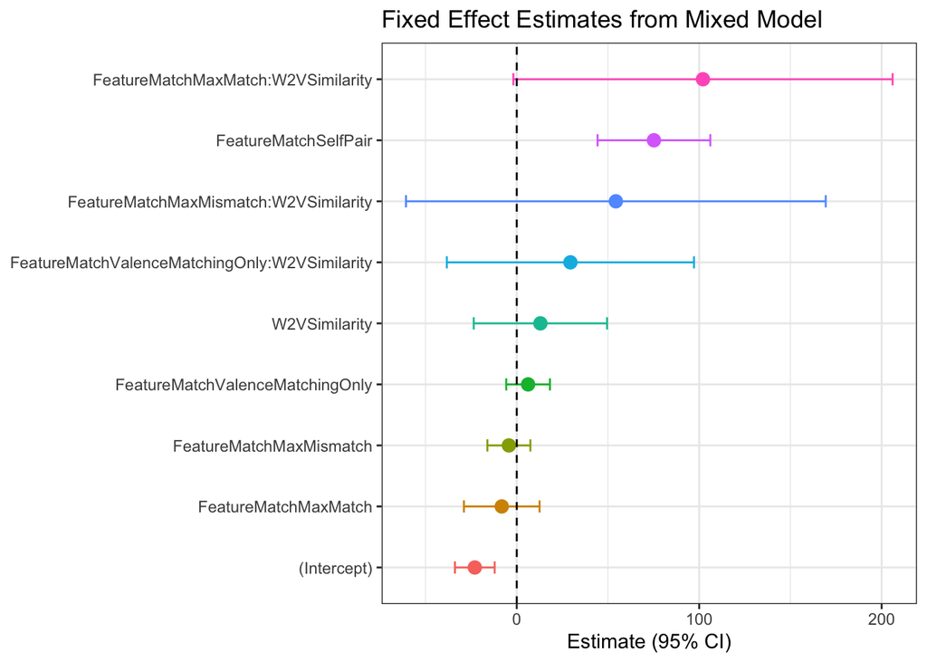

```r
# Tidy the model output
coefs <- tidy(m.full, effects = "fixed")

# Reorder by effect size for prettier plotting
coefs$term <- factor(coefs$term, levels = coefs$term[order(coefs$estimate)])

# Then replot
ggplot(coefs, aes(x = estimate, y = term, color = term)) +
  geom_point(size = 3) +
  geom_errorbarh(aes(xmin = estimate - 1.96 * std.error,
                     xmax = estimate + 1.96 * std.error), height = 0.2) +
  geom_vline(xintercept = 0, linetype = "dashed") +
  # theme_minimal(base_size = 14) +
  labs(title = "Fixed Effect Estimates from Mixed Model",
       x = "Estimate (95% CI)", y = NULL) +
  theme(legend.position="none")
```

### Plot predicted values vs. predictors

You can create a dataset of predicted values from your model and plot how the response changes with predictors:

1. Create a new dataset with combinations of predictors
- Generates all combinations of levels of FeatureMatch (a factor) and a sequence of W2VSimilarity values from -0.01 to 1 (100 points).
- Because: You want to predict your response across a continuous range of W2VSimilarity for each FeatureMatch group.

```r
newdata <- expand.grid(
  FeatureMatch = levels(dcen$FeatureMatch),
  W2VSimilarity = seq(-0.01, 1, length.out = 100)
)
```

2. Get predicted values and standard errors from the model

```r
pred <- predict(m.full, newdata = newdata, re.form = NA, se.fit = TRUE)
```

3. Add predictions and confidence intervals to newdata

```r
newdata$fit <- pred$fit
newdata$se <- pred$se.fit
newdata <- newdata %>%
  mutate(
    conf.low = fit - 1.96 * se,
    conf.high = fit + 1.96 * se
  )
```

4. Plot predicted lines with ribbons for confidence intervals

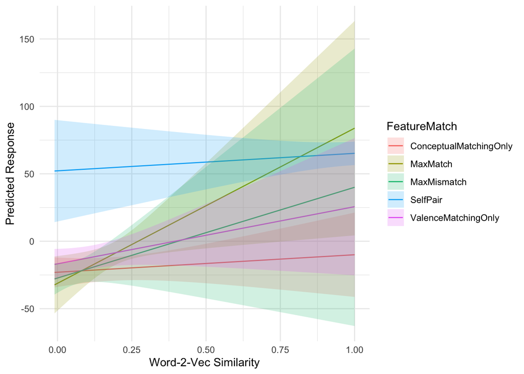

```r
ggplot(newdata, aes(x = W2VSimilarity, y = fit, color = FeatureMatch, fill = FeatureMatch)) +
  geom_line() +
  geom_ribbon(aes(ymin = conf.low, ymax = conf.high), alpha = 0.2, color = NA) +
  theme_minimal() +
  labs(x = "Word-2-Vec Similarity", y = "Predicted Response", color = "FeatureMatch", fill = "FeatureMatch")
```

### Visualize individual random effect estimates:

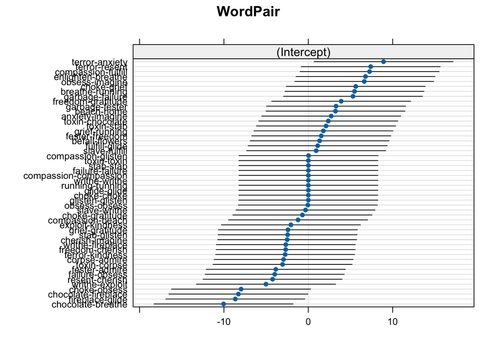

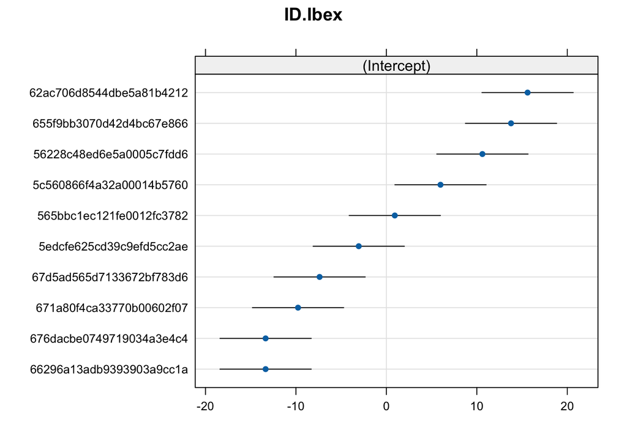

```r
dotplot(ranef(m.full, condVar=TRUE))
```

### Check model diagnostics

For residuals, fitted vs residuals, etc.:

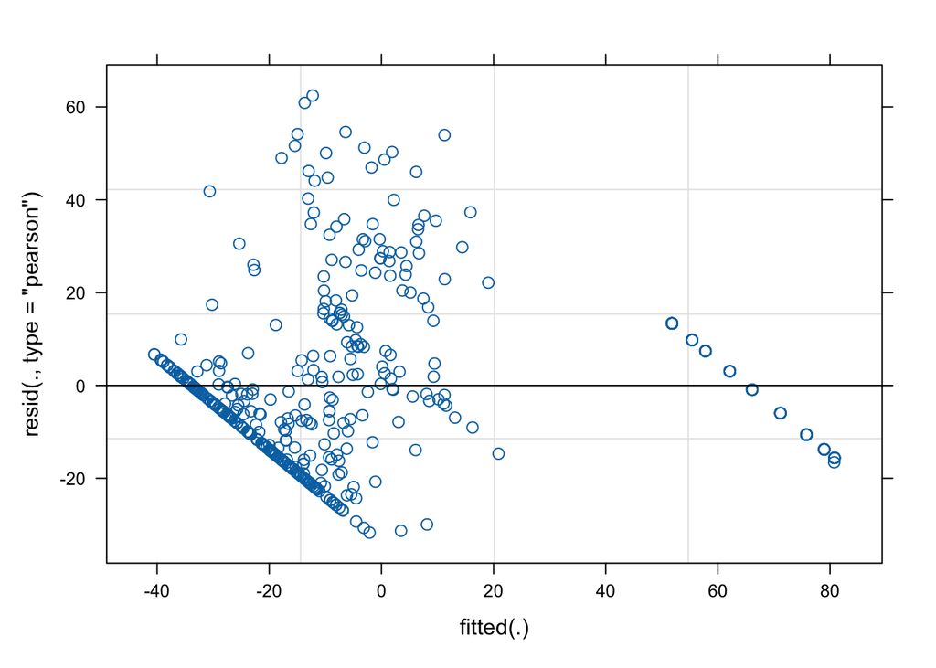

```r
plot(m.full)
```

# Similarity Alone

```r
m <- lmer(cResponse ~ W2VSimilarity + (1|WordPair) + (1|ID.Ibex), data = dcen)
summary(m)
```

```
## Linear mixed model fit by REML. t-tests use Satterthwaite's method [
## lmerModLmerTest]
## Formula: cResponse ~ W2VSimilarity + (1 | WordPair) + (1 | ID.Ibex)
##    Data: dcen
##
## REML criterion at convergence: 4374.5
##
## Scaled residuals:
##     Min      1Q  Median      3Q     Max
## -1.9079 -0.7060 -0.1005  0.4586  3.4537
##
## Random effects:
##  Groups   Name        Variance Std.Dev.
##  WordPair (Intercept)  82.5     9.083
##  ID.Ibex  (Intercept) 128.1    11.317
##  Residual             312.8    17.686
## Number of obs: 500, groups:  WordPair, 50; ID.Ibex, 10
##
## Fixed effects:
##               Estimate Std. Error      df t value Pr(>|t|)
## (Intercept)    -28.011      4.097  13.822  -6.838 8.66e-06 ***
## W2VSimilarity   90.565      4.216  47.999  21.483  < 2e-16 ***
## ---
## Signif. codes:  0 '***' 0.001 '**' 0.01 '*' 0.05 '.' 0.1 ' ' 1
##
## Correlation of Fixed Effects:
##             (Intr)
## W2VSimilrty -0.318
```

```r
m <- lmer(cResponse ~ CosineSimilarity + (1|WordPair) + (1|ID.Ibex), data = dcen)
summary(m)
```

```
## Linear mixed model fit by REML. t-tests use Satterthwaite's method [
## lmerModLmerTest]
## Formula: cResponse ~ CosineSimilarity + (1 | WordPair) + (1 | ID.Ibex)
##    Data: dcen
##
## REML criterion at convergence: 4370.5
##
## Scaled residuals:
##     Min      1Q  Median      3Q     Max
## -2.1836 -0.7093 -0.0993  0.4564  3.5477
##
## Random effects:
##  Groups   Name        Variance Std.Dev.
##  WordPair (Intercept)  74.04    8.605
##  ID.Ibex  (Intercept) 128.10   11.318
##  Residual             312.80   17.686
## Number of obs: 500, groups:  WordPair, 50; ID.Ibex, 10
##
## Fixed effects:
##                  Estimate Std. Error      df t value Pr(>|t|)
## (Intercept)       -45.574      4.365  17.382  -10.44 6.54e-09 ***
## CosineSimilarity  108.458      4.838  48.007   22.42  < 2e-16 ***
## ---
## Signif. codes:  0 '***' 0.001 '**' 0.01 '*' 0.05 '.' 0.1 ' ' 1
##
## Correlation of Fixed Effects:
##             (Intr)
## CosinSmlrty -0.466
```